# Week 06 - BankFlip

Alison

2024-02-28

```r
rm(list=ls())
library(tidyverse)
```

```r
library(rpart)
library(rpart.plot)
library(randomForest)
```

# Part 01: The data

https://www.kaggle.com/shrutimechlearn/churn-modelling

> This data set contains details of a bank’s customers and the target variable is a binary variable reflecting the fact whether the customer left the bank (closed their account) or they continue to be a customer.
- RowNumber Row Numbers from 1 to 10000
- CustomerId Unique Ids for bank customer identification
- Surname Customer’s last name
- CreditScore Credit score of the customer
- Geography The country from which the customer belongs
- Gender Male or Female
- Age Age of the customer
- Tenure Number of years for which the customer has been with the bank
- Balance Bank balance of the customer
- NumOfProducts Number of bank products the customer is utilising
- HasCrCard Binary Flag for whether the customer holds a credit card with the bank or not
- IsActiveMember Binary Flag for whether the customer is an active member with the bank or not
- EstimatedSalary Estimated salary of the customer in Dollars
- Exited Binary flag 1 if the customer closed account with bank and 0 if the customer is retained

```r
churn <- read_csv('./Churn_Modelling.csv')
glimpse(churn)
```

```
## Rows: 10,000
## Columns: 14
## $ RowNumber       <dbl> 1, 2, 3, 4, 5, 6, 7, 8, 9, 10, 11, 12, 13, 14, 15, 16,…
## $ CustomerId      <dbl> 15634602, 15647311, 15619304, 15701354, 15737888, 1557…
## $ Surname         <chr> "Hargrave", "Hill", "Onio", "Boni", "Mitchell", "Chu",…
## $ CreditScore     <dbl> 619, 608, 502, 699, 850, 645, 822, 376, 501, 684, 528,…
## $ Geography       <chr> "France", "Spain", "France", "France", "Spain", "Spain…
## $ Gender          <chr> "Female", "Female", "Female", "Female", "Female", "Mal…
## $ Age             <dbl> 42, 41, 42, 39, 43, 44, 50, 29, 44, 27, 31, 24, 34, 25…
## $ Tenure          <dbl> 2, 1, 8, 1, 2, 8, 7, 4, 4, 2, 6, 3, 10, 5, 7, 3, 1, 9,…
## $ Balance         <dbl> 0.00, 83807.86, 159660.80, 0.00, 125510.82, 113755.78,…
## $ NumOfProducts   <dbl> 1, 1, 3, 2, 1, 2, 2, 4, 2, 1, 2, 2, 2, 2, 2, 2, 1, 2, …
## $ HasCrCard       <dbl> 1, 0, 1, 0, 1, 1, 1, 1, 0, 1, 0, 1, 1, 0, 1, 0, 1, 1, …
## $ IsActiveMember  <dbl> 1, 1, 0, 0, 1, 0, 1, 0, 1, 1, 0, 0, 0, 0, 1, 1, 0, 1, …
## $ EstimatedSalary <dbl> 101348.88, 112542.58, 113931.57, 93826.63, 79084.10, 1…
## $ Exited          <dbl> 1, 0, 1, 0, 0, 1, 0, 1, 0, 0, 0, 0, 0, 0, 0, 0, 1, 0, …
```

Create a new outcome variable with labels.

```r
churn <- churn %>%
  mutate(exit = factor(Exited, labels = c('Stayed', 'Left'))) %>%
  mutate(Gender = as.factor(Gender))
```

Test it real quick to make sure it makes sense.

```r
table(churn$exit, churn$Exited)
```

```
##
##             0    1
##   Stayed 7963    0
##   Left      0 2037
```

The outcome variable is unbalanced. But not to a huge amount.

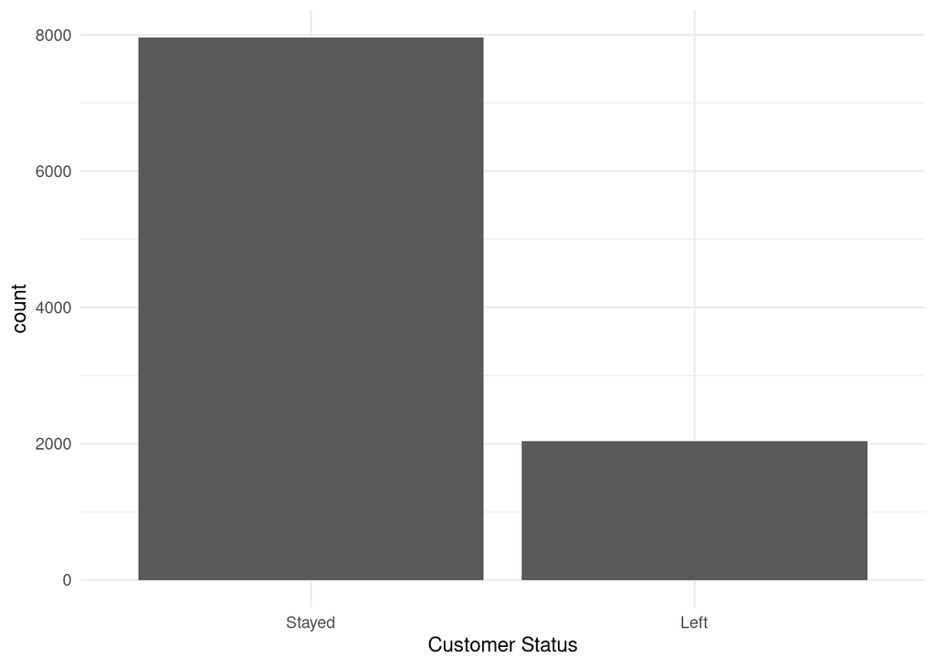

```r
ggplot(churn, aes(x = exit)) +
  geom_bar() +
  scale_x_discrete("Customer Status") +
  theme_minimal()
```

We want to predict if customers leave the bank. What if we just create a model that just naively states that everyone stays and never leaves? How accurate would we be?

```r
library(caret)
the_model_results <- factor(rep(0, nrow(churn)),
                            levels = c(0,1),
                            labels = c('Stayed', 'Left'))
the_actual_data <- churn$exit
confusionMatrix(the_model_results, the_actual_data)
```

```
## Confusion Matrix and Statistics
##
##           Reference
## Prediction Stayed Left
##     Stayed   7963 2037
##     Left        0    0
##
##                Accuracy : 0.7963
##                  95% CI : (0.7883, 0.8042)
##     No Information Rate : 0.7963
##     P-Value [Acc > NIR] : 0.5059
##
##                   Kappa : 0
##
##  Mcnemar's Test P-Value : <2e-16
##
##             Sensitivity : 1.0000
##             Specificity : 0.0000
##          Pos Pred Value : 0.7963
##          Neg Pred Value :    NaN
##              Prevalence : 0.7963
##          Detection Rate : 0.7963
##    Detection Prevalence : 1.0000
##       Balanced Accuracy : 0.5000
##
##        'Positive' Class : Stayed
##
```

Look at the accuracy value - why do you think the accuracy is so high? Any prediction model we build needs to be better than this!

Look at the specificity and sensitivity.

Sensitivity is the true positive rate. Here it is 1, as the model hasn’t seen any minority cases (“Left”), hence is treating `stayed` as the positive class.

Fit a basic decision tree to the `churn` data.

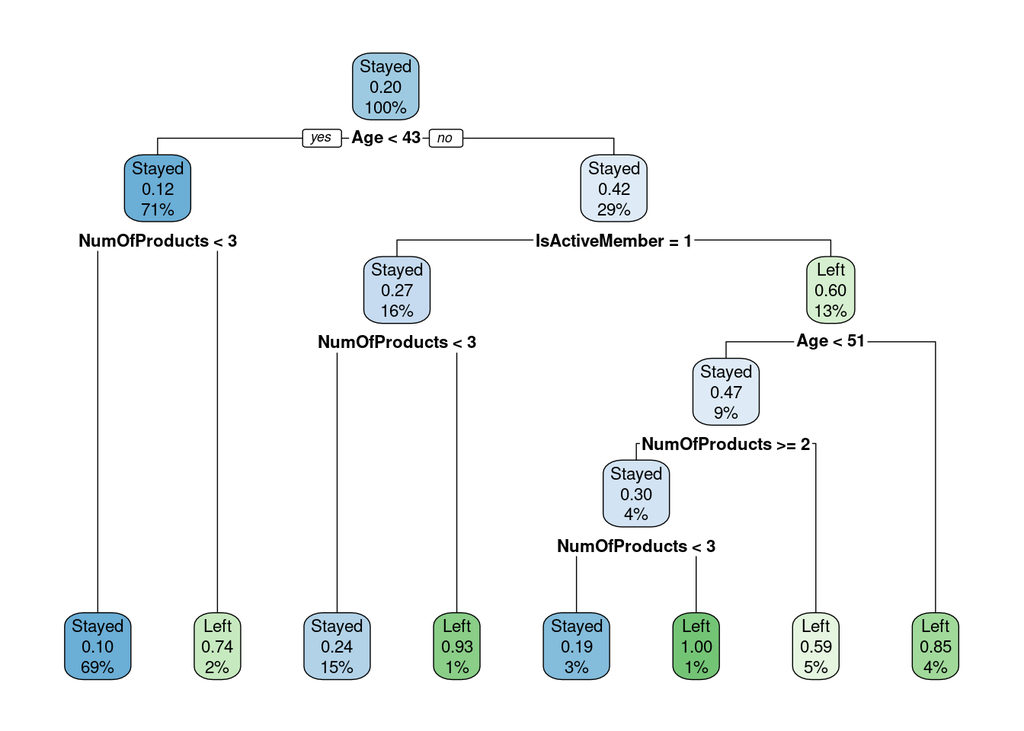

```r
churn_tree1 <- rpart(exit ~ Age + Gender + Tenure + Balance +
                       NumOfProducts + HasCrCard + IsActiveMember +
                       EstimatedSalary + CreditScore,
                     data = churn)
rpart.plot(churn_tree1)
```

This is better, but because leavers are relatively rare, the accuracy really doesn’t go up too much. The *specificity* got way better.

```r
p <- predict(churn_tree1)[,'Left']
the_model_results <- factor(ifelse(p > 0.5, 1, 0),
                            levels = c(0, 1),
                            labels = c('Stayed', 'Left'))
the_actual_data <- churn$exit
confusionMatrix(the_model_results, the_actual_data)
```

```
## Confusion Matrix and Statistics
##
##           Reference
## Prediction Stayed Left
##     Stayed   7641 1132
##     Left      322  905
##
##                Accuracy : 0.8546
##                  95% CI : (0.8475, 0.8615)
##     No Information Rate : 0.7963
##     P-Value [Acc > NIR] : < 2.2e-16
##
##                   Kappa : 0.474
##
##  Mcnemar's Test P-Value : < 2.2e-16
##
##             Sensitivity : 0.9596
##             Specificity : 0.4443
##          Pos Pred Value : 0.8710
##          Neg Pred Value : 0.7376
##              Prevalence : 0.7963
##          Detection Rate : 0.7641
##    Detection Prevalence : 0.8773
##       Balanced Accuracy : 0.7019
##
##        'Positive' Class : Stayed
##
```

Let’s make a really complex model.

> rpart.control()`is used to control the complexity parameter (cp) when building a decision tree using the`rpart package`.

> What does `cp = 0` do? The cp parameter stands for `complexity parameter` in the `rpart.control()` function. It prevents pruning by setting cp = 0, which means the tree continues growing until all possible splits are made. In most cases, this leads to an overly complex tree that is overfitted to the data.

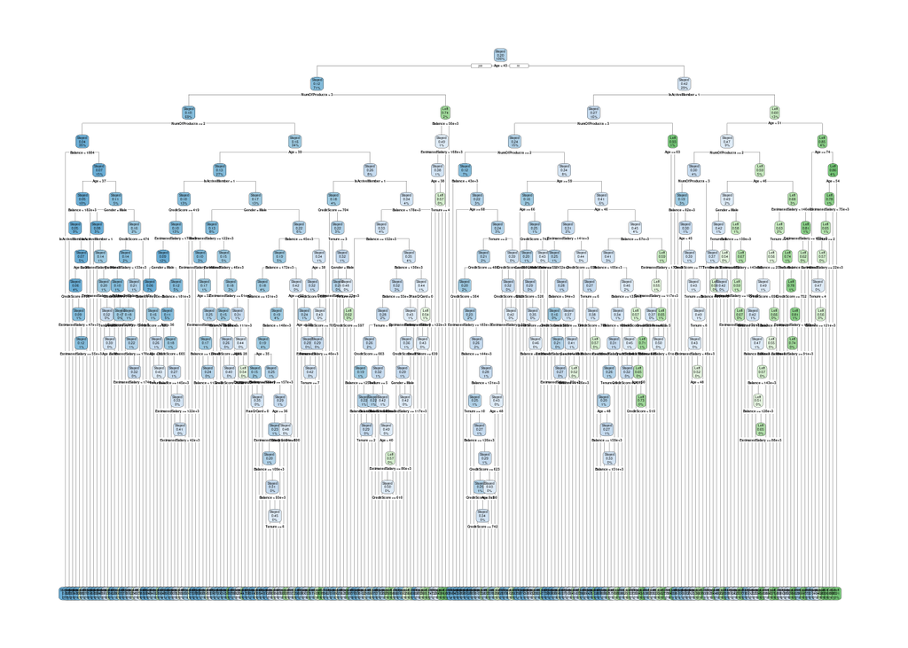

```r
churn_tree2 <- rpart(exit ~ Age + Gender + Tenure + Balance +
                       NumOfProducts + HasCrCard + IsActiveMember +
                       EstimatedSalary + CreditScore,
                     data = churn,
                     control = rpart.control(cp = 0))
rpart.plot(churn_tree2)
```

Did we gain anything from increasing the complexity?

```r
p <- predict(churn_tree2)[,'Left']
the_model_results <- factor(ifelse(p > 0.5, 1, 0),
                            levels = c(0, 1),
                            labels = c('Stayed', 'Left'))
the_actual_data <- churn$exit
confusionMatrix(the_model_results, the_actual_data)
```

```
## Confusion Matrix and Statistics
##
##           Reference
## Prediction Stayed Left
##     Stayed   7631  773
##     Left      332 1264
##
##                Accuracy : 0.8895
##                  95% CI : (0.8832, 0.8956)
##     No Information Rate : 0.7963
##     P-Value [Acc > NIR] : < 2.2e-16
##
##                   Kappa : 0.6295
##
##  Mcnemar's Test P-Value : < 2.2e-16
##
##             Sensitivity : 0.9583
##             Specificity : 0.6205
##          Pos Pred Value : 0.9080
##          Neg Pred Value : 0.7920
##              Prevalence : 0.7963
##          Detection Rate : 0.7631
##    Detection Prevalence : 0.8404
##       Balanced Accuracy : 0.7894
##
##        'Positive' Class : Stayed
##
```

# Part 02: ROC Curves and AUC

The output of the decision tree is a probability, not a 1 or 0. Using 0.50 is a natural threshold to try, but if you try different thresholds can you get a better output?

Let’s try it at 0.6:

```r
p <- predict(churn_tree2)[,'Left']
the_model_results <- factor(ifelse(p > 0.6, 1, 0),
                            levels = c(0, 1),
                            labels = c('Stayed', 'Left'))
the_actual_data <- churn$exit
cm <- confusionMatrix(the_model_results, the_actual_data)
```

We can plot and visualise - you can see the trade-off between the True Positive rate (sensitivity) and the True Negative rate (specificity) as you change the threshold:

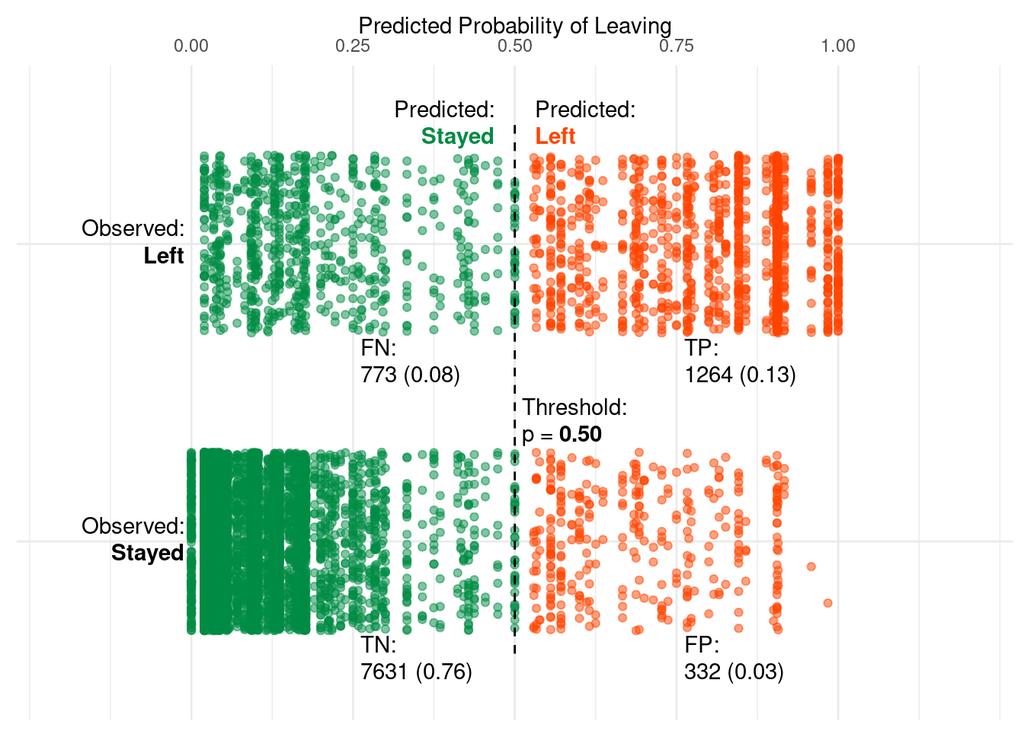

```r
library(ggtext)
## threshold for predicting positive outcome
p_threshold <- 0.5

## model predictions
churn_pred <- churn %>%
  mutate(p_exit = predict(churn_tree2)[,'Left']) %>%
  mutate(pred_exit = factor(ifelse(p_exit > p_threshold, 1, 0),
                levels = c(0, 1),
                labels = c('Stayed', 'Left')))

## confusion matrix
cm <- confusionMatrix(churn_pred$pred_exit,
                      churn_pred$exit)

## create some annotation messages
msg_tp <- sprintf("TP:<br> %d (%1.2f)", cm$table['Left', 'Left'], cm$table['Left', 'Left'] / nrow(churn))
msg_fp <- sprintf("FP:<br> %d (%1.2f)", cm$table['Left', 'Stayed'], cm$table['Left', 'Stayed'] / nrow(churn))
msg_tn <- sprintf("TN:<br> %d (%1.2f)", cm$table['Stayed', 'Stayed'], cm$table['Stayed', 'Stayed'] / nrow(churn))
msg_fn <- sprintf("FN:<br> %d (%1.2f)", cm$table['Stayed', 'Left'], cm$table['Stayed', 'Left'] / nrow(churn))


## create the plot
pal <- c("Left" = "#FF4500", "Stayed" = "#008B45")
ggplot(churn_pred, aes(x = p_exit, y = exit, color = pred_exit)) +
  geom_point(position = position_jitter(height = 0.3),
             alpha = 0.5) +
  scale_color_manual("Predicted\nOutcome",
                     values = pal,
                     labels = c(Left = "<span style='color:#FF4500'>Left</span>",
                                Stayed = "<span style='color:#008B45'>Stayed</span>")) +
  annotate(geom = "richtext", fill = NA, label.color = NA,
           x = p_threshold, y = 1.4, hjust = "left",
           label = sprintf("Threshold:<br>p = <b>%1.2f</b>", p_threshold)) +
  annotate(geom = 'segment', x = p_threshold, xend = p_threshold,
           y = 2.4, yend = 0.6, linetype = 2) +
  annotate(geom = "richtext", fill = NA, label.color = NA,
           x = p_threshold - 0.02, y = 2.4, hjust = "right",
           label = "Predicted:<br><b style='color:#008B45'>Stayed</b>") +
  annotate(geom = "richtext", fill = NA, label.color = NA,
           x = p_threshold + 0.02, y = 2.4, hjust = "left",
           label = "Predicted:<br><b style='color:#FF4500'>Left</b>") +
  annotate(geom = "richtext", fill = NA, label.color = NA,
           hjust = "left",
           x = p_threshold + (1 - p_threshold)/2,
           y = 1.6, label = msg_tp) +
  annotate(geom = "richtext", fill = NA, label.color = NA,
           hjust = "left",
           x = p_threshold/2,
           y = 0.6, label = msg_tn) +
  annotate(geom = "richtext", fill = NA, label.color = NA,
           hjust = "left",
           x = p_threshold + (1 - p_threshold)/2,
           y = 0.6, label = msg_fp) +
  annotate(geom = "richtext", fill = NA, label.color = NA,
           hjust = "left",
           x = p_threshold/2,
           y = 1.6, label = msg_fn) +
  annotate(geom = "richtext", fill = NA, label.color = NA,
           hjust = "right",
           x = 0,
           y = 2, label = "Observed:<br><b>Left</b>") +
  annotate(geom = "richtext", fill = NA, label.color = NA,
           hjust = "right",
           x = 0,
           y = 1, label = "Observed:<br><b>Stayed</b>") +
  scale_x_continuous(position = "top", breaks = seq(0, 1, length.out = 5)) +
  xlab("Predicted Probability of Leaving") +
  theme_minimal() +
  theme(legend.position = 'none', axis.text = element_markdown(),
        axis.text.y = element_blank(), axis.title.y = element_blank()) +
  coord_cartesian(xlim = c(-0.2, 1.2))
```

Let’s try all the thresholds and see what value we get for them all.

```r
p <- predict(churn_tree2)[,'Left'] #predicted probabilities of 'left'
ks <- seq(0,1,length.out = 100)

all_threshold <- lapply(ks, function(k) {
  the_model_results <- factor(ifelse(p > k, 1, 0),
                              levels = c(0, 1),
                              labels = c('Stayed', 'Left'))
  the_actual_data <- churn$exit
  cm <- confusionMatrix(the_model_results, the_actual_data)
  tibble(accuracy = cm$overall['Accuracy'],
         sens = cm$byClass['Sensitivity'],
         spec = cm$byClass['Specificity'])
}) %>% bind_rows() %>%
  mutate(threshold = ks)
```

Plot the accuracy, sensitivity, and specificity for each threshold.

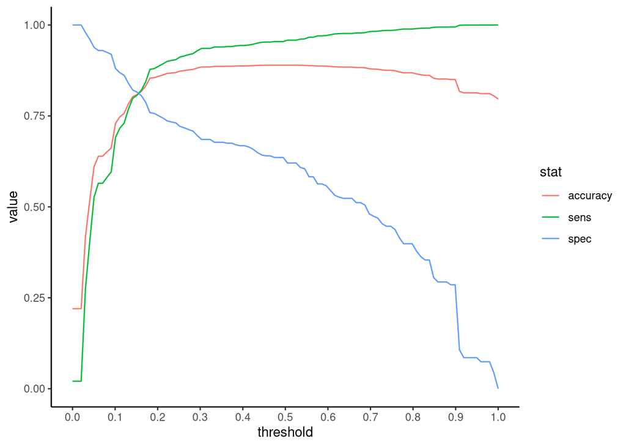

```r
ggplot(gather(all_threshold, stat, value, -threshold),
       aes(x = threshold, y = value, group = stat, color = stat)) +
  geom_line() +
  scale_x_continuous(breaks = seq(0,1,by =0.1)) +
  theme_classic()
```

Another way of plotting this data is with the x-axis as the Specificity and the y-axis as the Sensitivity. Actually, we reverse the x-axis, as a ROC plot actually plots sensitivity (True Positive rate) against 1-Specificity (False Positive rate)

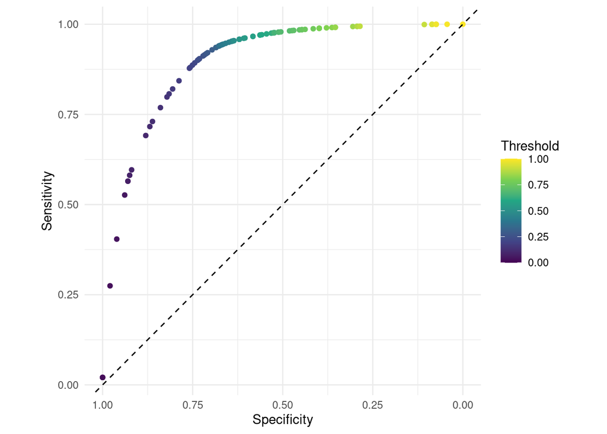

```r
ggplot(data = all_threshold, aes(x = spec, y = sens, color = threshold)) +
  geom_point() +
  scale_color_viridis_c('Threshold') +
  geom_abline(intercept = 1, slope = 1, linetype = 2) +
  scale_x_reverse() +
  coord_equal() +
  labs(y = 'Sensitivity', x = 'Specificity') +
  theme_minimal()
```

`pROC` is a package just for ROC curves like this. Use asp=NA to control scaling

```r
library(pROC)
pred <- tibble(p_exit = as.numeric(predict(churn_tree2)[,'Left']),
               exit = churn$Exited)
churn_roc1 <- roc(data = pred, response = exit, predictor = p_exit)
```

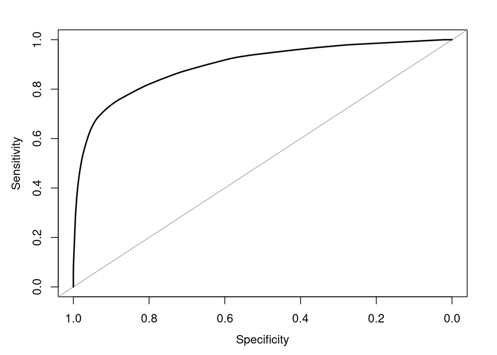

```r
plot(churn_roc1, asp=NA)
```

The AUC or Area Under the Curve is the measure of predictive performance for the model.

Interpretation:  
AUC = 1.0 Perfect classification.  
AUC = 0.5 Random guessing (bad model).  
AUC < 0.5 Worse than random (something is wrong).

```r
auc(churn_roc1)
```

```
## Area under the curve: 0.8946
```

`ggroc()` creates a ROC curve with more control over aesthetics:

Adds a diagonal reference line (geom_abline()) to compare against random guessing.

Annotates the AUC score on the plot.

Uses coord_equal() to ensure correct scaling.

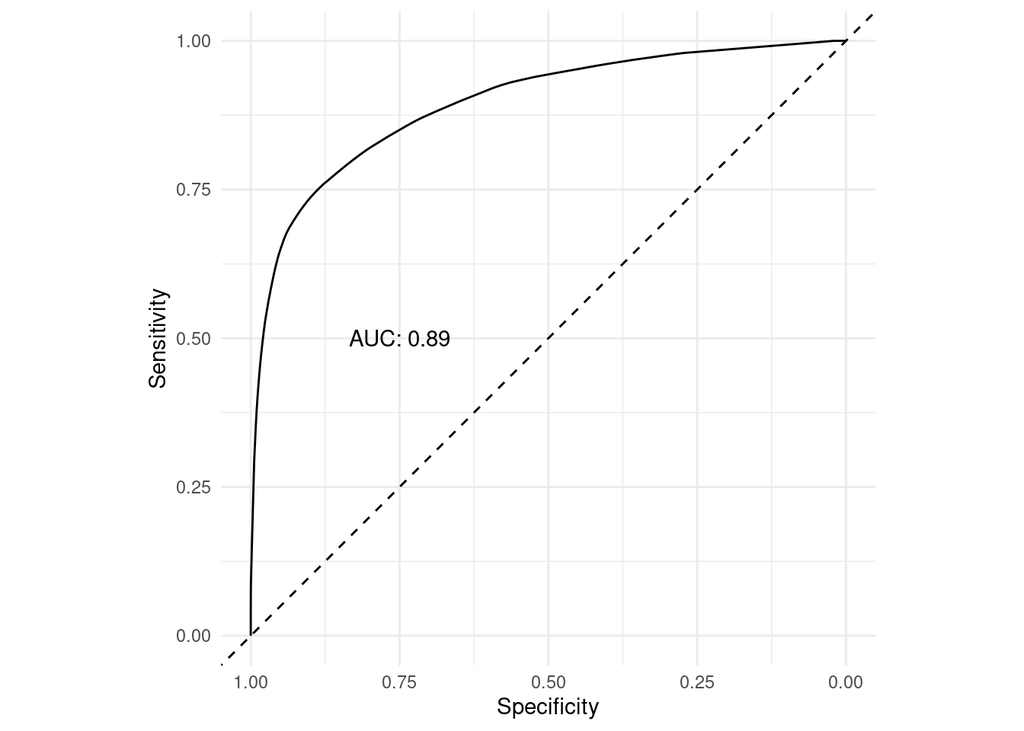

```r
ggroc(churn_roc1) +
  geom_abline(intercept = 1, slope = 1, linetype = 2) +
  annotate('text', x = 0.75, y = 0.5,
           label = sprintf('AUC: %1.2f', churn_roc1$auc)) +
  labs(y = 'Sensitivity', x = 'Specificity') +
  coord_equal() +
  theme_minimal()
```

We can ask the ROC object what the best threshold would be to maximize both sensitivity and specificity. It’s considerably different from 0.5

```r
coords(churn_roc1, 'best')
```

```
##   threshold specificity sensitivity
## 1 0.2034483   0.8867261   0.7506136
```

We can add it to the plot:

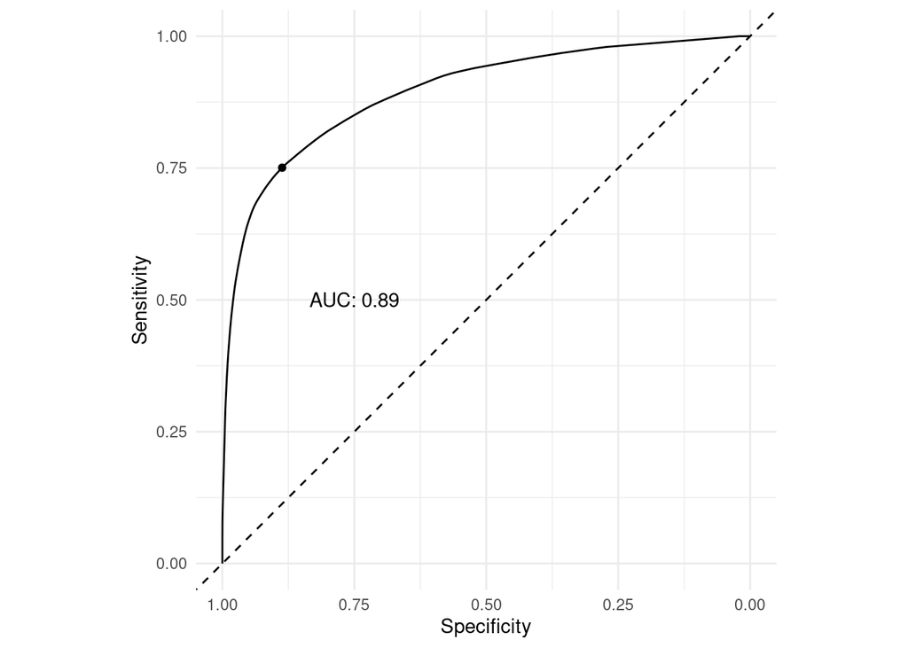

```r
best_coords <- coords(churn_roc1, 'best')
ggroc(churn_roc1) +
  geom_abline(intercept = 1, slope = 1, linetype = 2) +
  annotate('text', x = 0.75, y = 0.5,
           label = sprintf('AUC: %1.2f', churn_roc1$auc)) +
  annotate('point', x = best_coords$specificity,
           y = best_coords$sensitivity) +
  labs(y = 'Sensitivity', x = 'Specificity') +
  coord_equal() +
  theme_minimal()
```

This code is computing a confusion matrix using a custom threshold (best_coords$threshold), which is obtained from the ROC analysis. The sensitivity and specificity are maximised.

```r
p <- predict(churn_tree2)[,'Left']
the_model_results <- factor(ifelse(p > best_coords$threshold, 1, 0),
                            levels = c(0, 1),
                            labels = c('Stayed', 'Left'))
the_actual_data <- churn$exit
confusionMatrix(the_model_results, the_actual_data)
```

```
## Confusion Matrix and Statistics
##
##           Reference
## Prediction Stayed Left
##     Stayed   7061  508
##     Left      902 1529
##
##                Accuracy : 0.859
##                  95% CI : (0.852, 0.8658)
##     No Information Rate : 0.7963
##     P-Value [Acc > NIR] : < 2.2e-16
##
##                   Kappa : 0.5945
##
##  Mcnemar's Test P-Value : < 2.2e-16
##
##             Sensitivity : 0.8867
##             Specificity : 0.7506
##          Pos Pred Value : 0.9329
##          Neg Pred Value : 0.6290
##              Prevalence : 0.7963
##          Detection Rate : 0.7061
##    Detection Prevalence : 0.7569
##       Balanced Accuracy : 0.8187
##
##        'Positive' Class : Stayed
##
```

We can present our outcomes in different ways. Why might you want to do this? Here are a couple of examples:

## Lift curve

A Lift Curve is a powerful tool for evaluating how well a predictive model identifies churners (exits) compared to random guessing. It provides actionable insights into model effectiveness.

X-axis (perc_pop): The proportion of the population examined (from highest to lowest predicted exit probability). Y-axis (Lift): How much better the model is at identifying churners than a random selection of customers.

A lift of 1.0 means the model is performing no better than random guessing. A lift > 1.0 means the model is identifying exits better than random. The higher the lift, the better the model’s predictive power.

```r
# Define population cutoffs
top_x_percentages <- c(0.05, 0.10, 0.20, 0.50)  # Top 5%, 10%, 20%, 50%

# Compute ranked lift curve
nr <- nrow(pred)
pred2 <- pred %>%
  arrange(desc(p_exit)) %>%  # Sort by predicted churn probability
  mutate(rn = row_number()) %>%  # Assign rank
  mutate(perc_pop = rn / nr) %>%  # Compute % of the population seen
  mutate(exit_sum = cumsum(exit)) %>%  # Cumulative sum of actual exits
  mutate(exit_p = exit_sum / sum(exit)) %>%  # Percentage of total exits identified
  mutate(lift = exit_p / perc_pop)  # Compute lift

# Compute lift at different top X% cutoffs
top_x_lift <- pred2 %>%
  filter(perc_pop %in% top_x_percentages) %>%
  select(perc_pop, lift)

# Print results
print(top_x_lift)
```

```
## # A tibble: 4 × 2
##   perc_pop  lift
##      <dbl> <dbl>
## 1     0.05  4.63
## 2     0.1   4.36
## 3     0.2   3.49
## 4     0.5   1.83
```

Let’s visualise it:

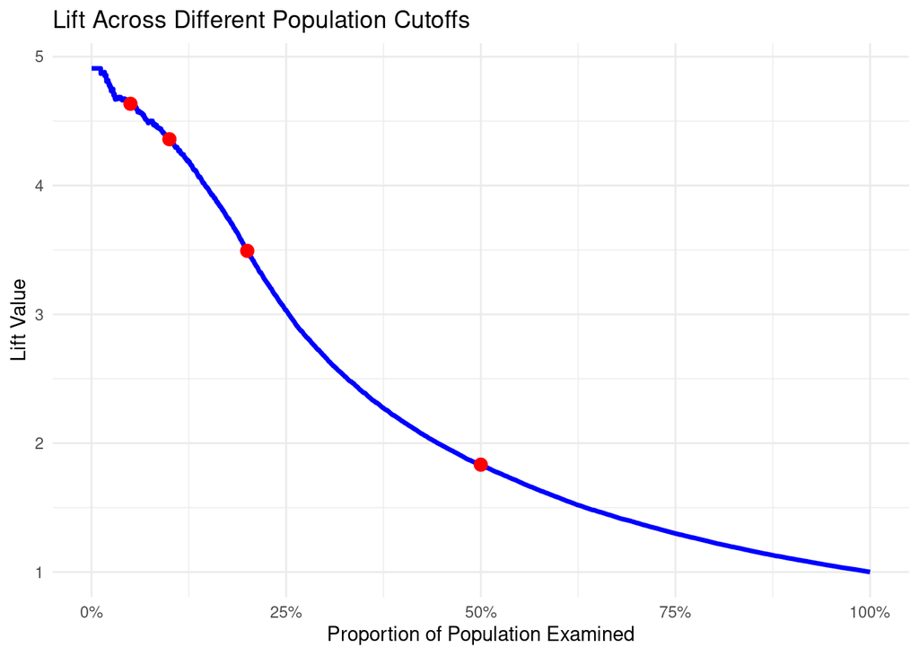

```r
ggplot(pred2, aes(x = perc_pop, y = lift)) +
  geom_line(color = "blue", size = 1.2) +
  geom_point(data = top_x_lift, aes(x = perc_pop, y = lift), color = "red", size = 3) +
  scale_x_continuous(labels = scales::percent) +  # Convert X-axis to percentage
  labs(title = "Lift Across Different Population Cutoffs",
       x = "Proportion of Population Examined",
       y = "Lift Value") +
  theme_minimal()
```

## Density plots

Separation Between Stayed vs. Left Customers:

Impact of the Decision Threshold (Vertical Line):

The dashed black threshold line represents the cutoff for classification. Customers to the right of this line are predicted as “Left” (churners), while those to the left are predicted as “Stayed.”  
Misclassification Issues:

Implications for Decision-Making:

Lowering the threshold (moving the line left) catches more churners (higher recall) but increases false alarms (lower precision). Raising the threshold (moving the line right) reduces false alarms but misses more actual churners (lower recall). A well-placed threshold balances false positives and false negatives, depending on business needs.

When to Adjust the Threshold?

If the cost of losing a customer is high, use a lower threshold (higher recall, even if it causes more false positives).

If false churn alerts are costly (e.g., retention campaigns are expensive), use a higher threshold (reducing false positives).

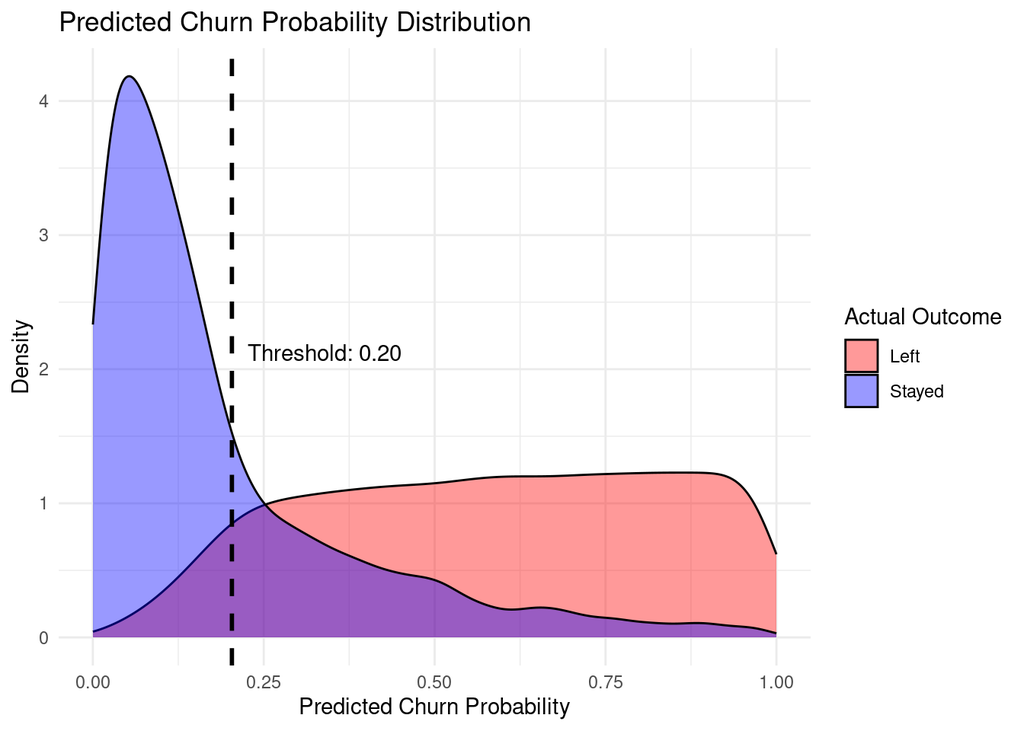

```r
threshold_value <- best_coords[1,1]

ggplot(pred2, aes(x = perc_pop, fill = factor(exit))) +
  geom_density(alpha = 0.4) +
  scale_fill_manual(values = c("red", "blue"), labels = c("Left", "Stayed")) +  # Ensure correct mapping
  geom_vline(xintercept = threshold_value, linetype = "dashed", color = "black", linewidth = 1) +
  annotate("text", x = threshold_value, y = 2, label = sprintf("Threshold: %.2f", threshold_value),
           color = "black", vjust = -0.5, hjust = -0.1) +
  labs(title = "Predicted Churn Probability Distribution",
       x = "Predicted Churn Probability", y = "Density", fill = "Actual Outcome") +
  theme_minimal()
```

# Part 03: Cross Validation

Create cross validation samples. We will actually just use one as a hold-out set here

```r
churn$set <- sample(1:10, nrow(churn), replace = T)
churn_train <- filter(churn, set != 1)
churn_test <- filter(churn, set == 1)
dim(churn)
```

```
## [1] 10000    16
```

```r
dim(churn_train)
```

```
## [1] 9056   16
```

```r
dim(churn_test)
```

```
## [1] 944  16
```

## Decision trees

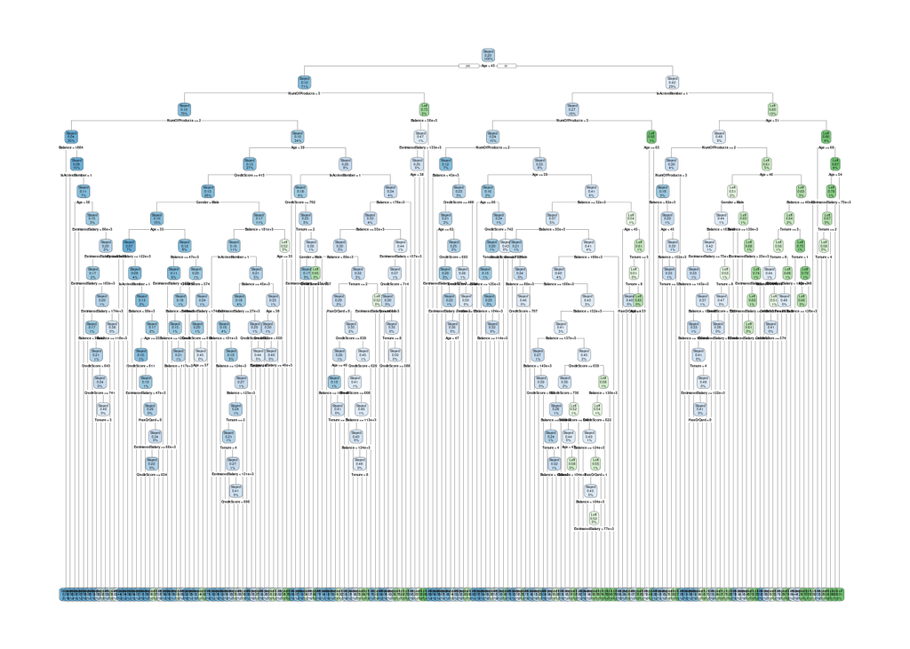

```r
churn_tree3 <- rpart(exit ~ Age + Gender + Tenure + Balance +
                       NumOfProducts + HasCrCard + IsActiveMember +
                       EstimatedSalary + CreditScore,
                     data = churn_train,
                     control = rpart.control(cp = 0))
rpart.plot(churn_tree3)
```

```r
predict(churn_tree3, newdata = churn_test) %>% head
```

```
##      Stayed       Left
## 1 0.9795699 0.02043011
## 2 0.8214286 0.17857143
## 3 0.9618768 0.03812317
## 4 0.2083333 0.79166667
## 5 0.2500000 0.75000000
## 6 0.1538462 0.84615385
```

Checking out the ROC and AUC for the training set.

```r
pred <- tibble(p_exit = predict(churn_tree3, newdata = churn_train)[,'Left'],
               exit = churn_train$Exited)
churn_roc <- roc(data = pred, response = exit, predictor = p_exit)
churn_roc$auc
```

```
## Area under the curve: 0.889
```

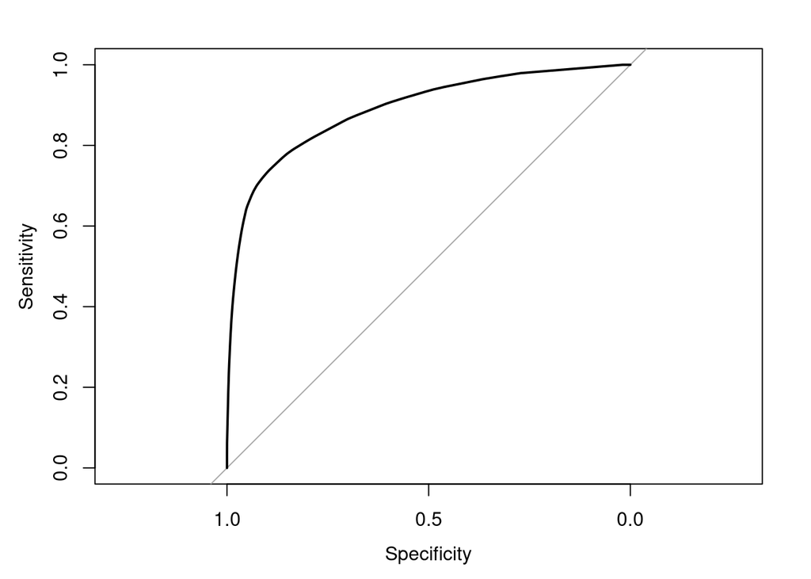

```r
plot(churn_roc)
```

Checking out the ROC and AUC for the test set.

```r
pred <- tibble(p_exit = predict(churn_tree3, newdata = churn_test)[,'Left'],
               exit = churn_test$Exited)
churn_roc <- roc(data = pred, response = exit, predictor = p_exit)
churn_roc$auc
```

```
## Area under the curve: 0.7999
```

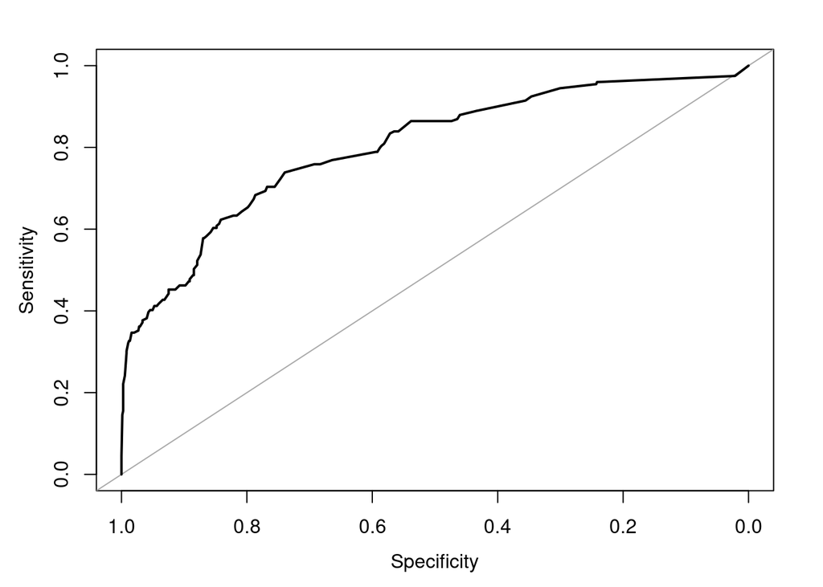

```r
plot(churn_roc, asp=NA)
```

The *complexity parameter* (`cp`) controls the minimum improvement necessary in order to create a new split of the data. The smaller the value, the smaller the improvement needs to be, and as a result you see more splits of the data. It turns into lots of splits to get tiny improvements. But this can result in overfitting to outlies or idiosyncracies of the training set and won’t generalize to new data.

Let’s test how different values of the complexity parameter (cp) impact training and test accuracy in a decision tree model (rpart). This helps identify the best trade-off between model complexity and generalization.

What do you see? What would be the best cp?

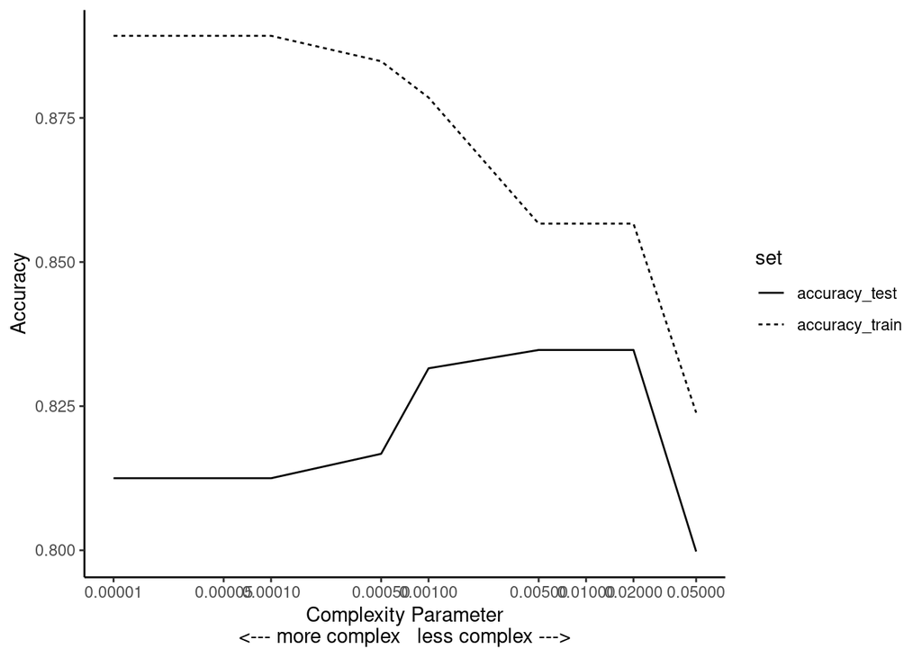

```r
churn_form <- exit ~ Age + Gender + Tenure + Balance +
                       NumOfProducts + HasCrCard + IsActiveMember +
                       EstimatedSalary + CreditScore
cp_seq <- c(0.05, 0.02, 0.01, 0.005, 0.001, 0.0005, 0.0001, 0.00005, 0.00001)
train_test_accuracy <- function(k) {
  churn_tree4 <- rpart(churn_form, data = churn_train,
                       control = rpart.control(cp = k))
  accuracy_train <- predict(churn_tree4, newdata = churn_train)[,'Left'] %>%
    { ifelse(. > 0.5, 1, 0)} %>%
    { . == churn_train$Exited} %>%
    { sum(.) / length(.)}
  accuracy_test <- predict(churn_tree4, newdata = churn_test)[,'Left'] %>%
    { ifelse(. > 0.5, 1, 0)} %>%
    { . == churn_test$Exited} %>%
    { sum(.) / length(.)}
  tibble(accuracy_train = accuracy_train, accuracy_test = accuracy_test)
}

d <- lapply(cp_seq, train_test_accuracy) %>%
  bind_rows %>%
  mutate(cp = cp_seq)

ggplot(gather(d, set, value, -cp),
       aes(x = cp, y = value, group = set, linetype = set)) +
  geom_line() +
  scale_x_log10(breaks = cp_seq, labels = sprintf('%1.5f', cp_seq)) +
  # scale_y_continuous(limits = c(0,1)) + # note the y-scale
  labs(x = 'Complexity Parameter\n<--- more complex   less complex --->',
       y = 'Accuracy') +
  theme_classic()
```

We could experiment with “pruning” our tree.  
CP Table: Each row shows a potential pruning point. xerror (Cross-validation error): Helps select the optimal subtree.

```r
printcp(churn_tree3)
```

```
##
## Classification tree:
## rpart(formula = exit ~ Age + Gender + Tenure + Balance + NumOfProducts +
##     HasCrCard + IsActiveMember + EstimatedSalary + CreditScore,
##     data = churn_train, control = rpart.control(cp = 0))
##
## Variables actually used in tree construction:
## [1] Age             Balance         CreditScore     EstimatedSalary
## [5] Gender          HasCrCard       IsActiveMember  NumOfProducts
## [9] Tenure
##
## Root node error: 1838/9056 = 0.20296
##
## n= 9056
##
##            CP nsplit rel error  xerror     xstd
## 1  0.06610446      0   1.00000 1.00000 0.020824
## 2  0.03536453      2   0.86779 0.89010 0.019920
## 3  0.03482046      4   0.79706 0.84603 0.019526
## 4  0.03046790      5   0.76224 0.78618 0.018960
## 5  0.02557127      6   0.73177 0.73993 0.018496
## 6  0.00380849      7   0.70620 0.71763 0.018264
## 7  0.00353645     10   0.69314 0.72579 0.018350
## 8  0.00272035     12   0.68607 0.71545 0.018241
## 9  0.00258433     13   0.68335 0.71872 0.018275
## 10 0.00163221     17   0.67301 0.73286 0.018423
## 11 0.00136017     22   0.66485 0.73885 0.018485
## 12 0.00126950     34   0.63874 0.73776 0.018474
## 13 0.00119695     39   0.63112 0.73830 0.018480
## 14 0.00108814     50   0.61589 0.73830 0.018480
## 15 0.00072543     65   0.59848 0.75245 0.018624
## 16 0.00054407     90   0.57889 0.75571 0.018657
## 17 0.00043526    108   0.56746 0.77911 0.018891
## 18 0.00040805    119   0.56257 0.78509 0.018949
## 19 0.00036271    125   0.55930 0.79489 0.019045
## 20 0.00027203    136   0.55441 0.80359 0.019129
## 21 0.00020403    140   0.55332 0.82318 0.019314
## 22 0.00018136    149   0.55114 0.83351 0.019411
## 23 0.00013602    159   0.54897 0.83841 0.019456
## 24 0.00000000    175   0.54570 0.85092 0.019571
```

```r
best_cp <- churn_tree3$cptable[which.min(churn_tree3$cptable[,"xerror"]), "CP"]
print(best_cp)
```

```
## [1] 0.002720348
```

Prune the tree! Remove splits that don’t significantly improve predictive power. Keep the best balance between complexity and generalization.

```r
churn_tree_pruned <- prune(churn_tree3, cp = best_cp)
```

Visualise the pruned tree

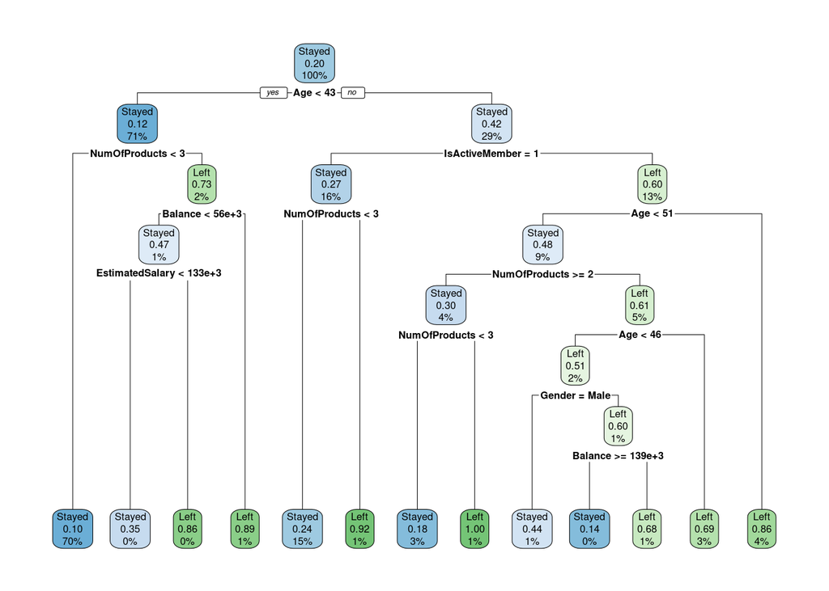

```r
rpart.plot(churn_tree_pruned)
```

## Random Forest

```r
churn_rf <- randomForest(exit ~ Age + Gender + Tenure + Balance +
                       NumOfProducts + HasCrCard + IsActiveMember +
                       EstimatedSalary + CreditScore,
                     data = churn_train)
```

```r
p_train <- predict(churn_rf, type = 'prob')[,'Left']
the_model_results <- factor(ifelse(p_train > 0.45, 1, 0),
                            levels = c(0, 1),
                            labels = c('Stayed', 'Left'))
the_actual_data <- churn_train$exit
confusionMatrix(the_model_results, the_actual_data)
```

```
## Confusion Matrix and Statistics
##
##           Reference
## Prediction Stayed Left
##     Stayed   6860  976
##     Left      358  862
##
##                Accuracy : 0.8527
##                  95% CI : (0.8452, 0.8599)
##     No Information Rate : 0.797
##     P-Value [Acc > NIR] : < 2.2e-16
##
##                   Kappa : 0.4795
##
##  Mcnemar's Test P-Value : < 2.2e-16
##
##             Sensitivity : 0.9504
##             Specificity : 0.4690
##          Pos Pred Value : 0.8754
##          Neg Pred Value : 0.7066
##              Prevalence : 0.7970
##          Detection Rate : 0.7575
##    Detection Prevalence : 0.8653
##       Balanced Accuracy : 0.7097
##
##        'Positive' Class : Stayed
##
```

```r
pred <- tibble(p_exit = p_train, exit = churn_train$Exited)
churn_roc_train <- roc(data = pred, response = exit, predictor = p_exit)
```

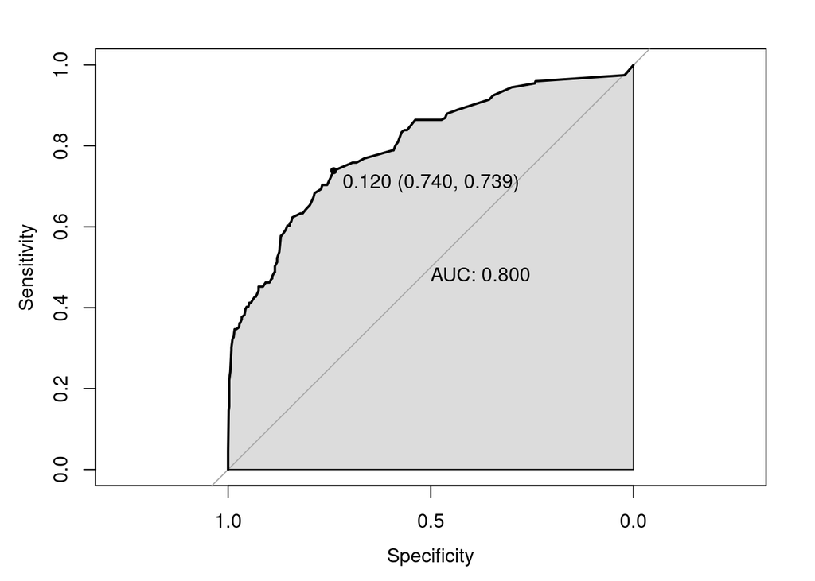

```r
plot(churn_roc, print.auc = T, auc.polygon = T, print.thres = 'best')
```

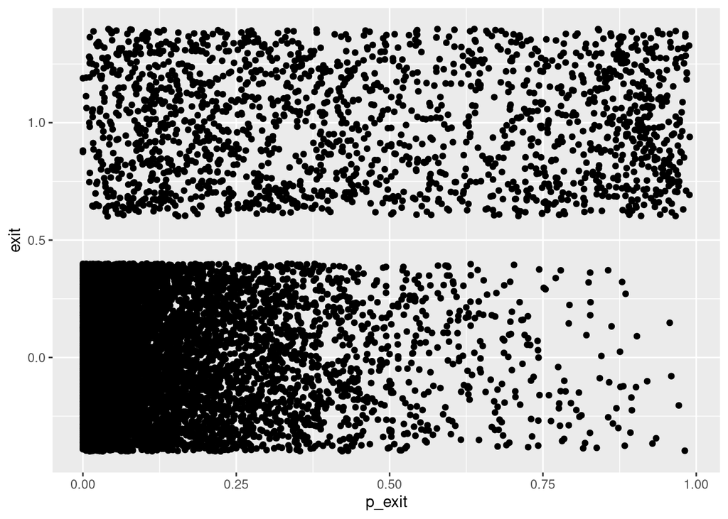

```r
ggplot(pred) +
  geom_jitter(aes(x = p_exit, y = exit))
```

```r
coords(churn_roc, 'best', transpose = FALSE)
```

```
##   threshold specificity sensitivity
## 1 0.1197723   0.7395973   0.7386935
```

```r
p_test <- predict(churn_rf, newdata = churn_test, type = 'prob')[,'Left']
pred_test <- tibble(p_exit = p_test,exit = churn_test$Exited)
churn_roc_test <- roc(data = pred_test, response = exit, predictor = p_exit)
```

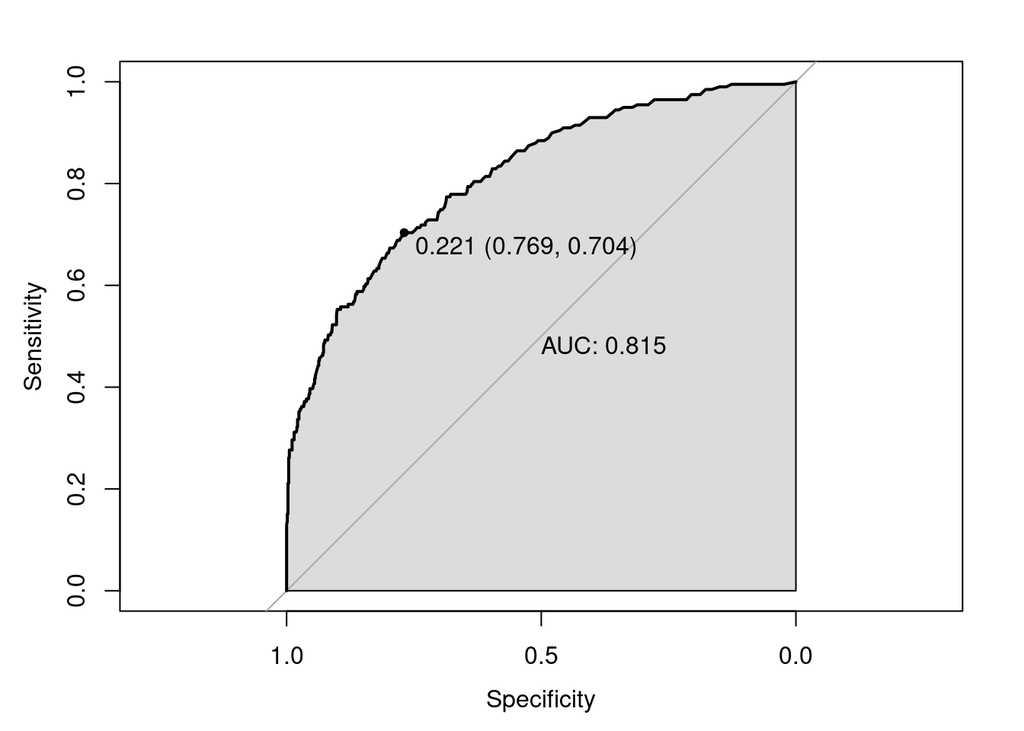

```r
plot(churn_roc_test, print.auc = T, auc.polygon = T, print.thres = 'best')
```

Plot a comparison of test and train.

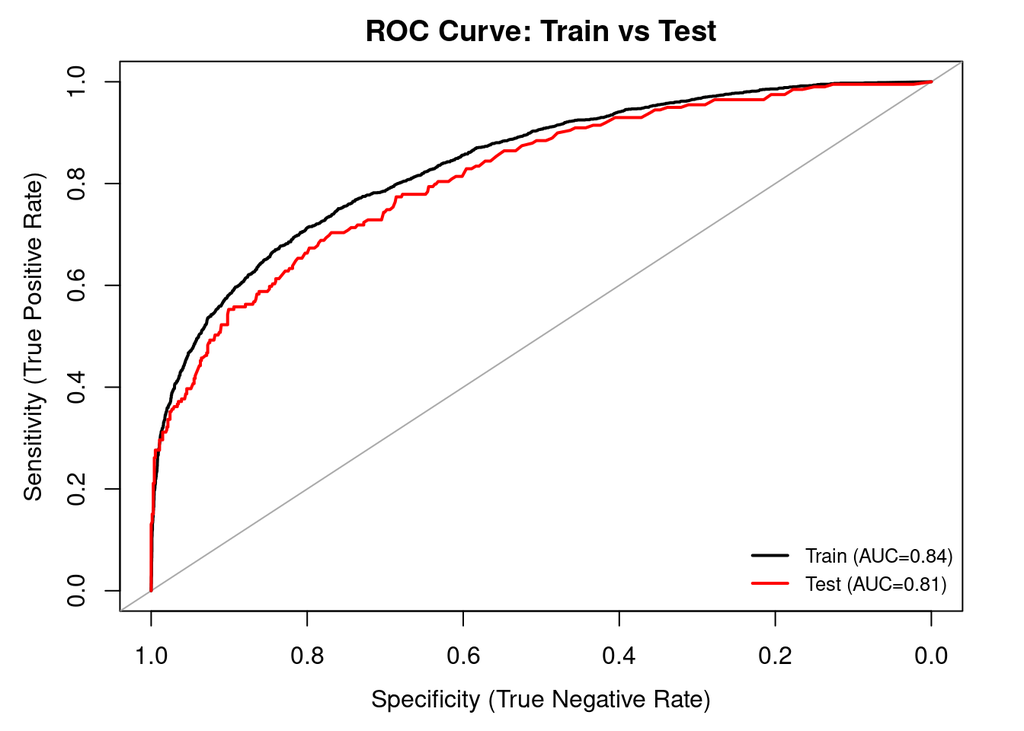

```r
# Plot Train ROC first (sets the correct scale)
plot(churn_roc_train, col = "black", lwd = 2,
     xlim = c(1, 0), ylim = c(0, 1),  # Ensure correct axis scaling
     asp = NA,
     xlab = "Specificity (True Negative Rate)",
     ylab = "Sensitivity (True Positive Rate)",
     main = "ROC Curve: Train vs Test")

# Add Test ROC (ensure it aligns correctly)
plot(churn_roc_test, add = TRUE, col = "red", lwd = 2)

# Add a legend with reduced font size
legend("bottomright",  # Automatic positioning
       legend = c(sprintf("Train (AUC=%1.2f)", auc(churn_roc_train)),
                  sprintf("Test (AUC=%1.2f)", auc(churn_roc_test))),
       col = c("black", "red"),
       lty = 1, lwd = 2,
       cex = 0.8, # Reduce font size (default is 1.0)
       pt.cex = 0.5, # Reduce legend size
       bty = "n")  # Remove box around legend
```

# Part 04: Trying CV with Caret

```r
library(caret)
```

Use cross validation and a range of mtry parameters to define training control parameters.

`mtry` controls how many features are randomly chosen at each split in the Random Forest.

We can create a manual grid to test, e.g:  
> # Define a tuning grid - > mtry_values <- seq(2, 4) > tuneGrid = expand.grid(.mtry = mtry_values)

> Then set `tuneGrid = tuneGrid`.

```r
train_control <- trainControl(method = 'cv',
                              number = 10,
                              savePredictions = 'final',
                              classProbs = TRUE,
                              verboseIter = TRUE)

churn_cv <- train(exit ~ Age + Gender + Tenure + Balance +
             NumOfProducts + HasCrCard + IsActiveMember +
             EstimatedSalary + CreditScore,
             data = churn_train,
             trControl = train_control,
             preProcess = c('center', 'scale'),
             tunelength = 5,
             method = 'rf')
#churn_cv_eval <- evalm(churn_cv)
confusionMatrix(churn_cv$pred$pred, churn_cv$pred$obs)
```

```
## Confusion Matrix and Statistics
##
##           Reference
## Prediction Stayed Left
##     Stayed   7030 1107
##     Left      188  731
##
##                Accuracy : 0.857
##                  95% CI : (0.8496, 0.8642)
##     No Information Rate : 0.797
##     P-Value [Acc > NIR] : < 2.2e-16
##
##                   Kappa : 0.4568
##
##  Mcnemar's Test P-Value : < 2.2e-16
##
##             Sensitivity : 0.9740
##             Specificity : 0.3977
##          Pos Pred Value : 0.8640
##          Neg Pred Value : 0.7954
##              Prevalence : 0.7970
##          Detection Rate : 0.7763
##    Detection Prevalence : 0.8985
##       Balanced Accuracy : 0.6858
##
##        'Positive' Class : Stayed
##
```

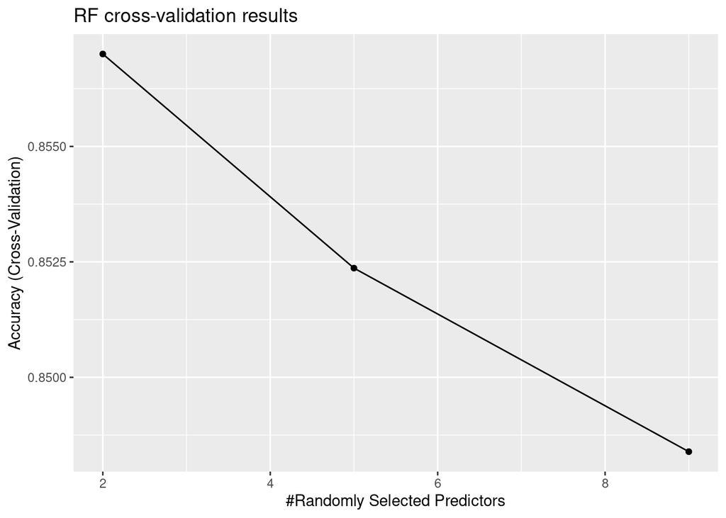

```r
ggplot(churn_cv) +
  labs(title = "RF cross-validation results")
```

The cross-validation chooses the best mtry. We can plot the cross-validation results and see how accuracy changes across differnt `mtry`

```r
rf_cv <- churn_cv$finalModel
```

After training with caret::train(), the predictions from all cross-validation folds are stored in `chrun_cv$pred`.

This contains:  
.mtry: The hyperparameter value for that model.  
obs: The actual class labels (Stayed or Left).  
pred: The predicted class (Stayed or Left).  
Class probabilities for each class (e.g., Stayed, Left).

We can plot all cross-validation predictions together, treating them as one single dataset. It does not show separate ROC curves for each fold. The resulting ROC curve is an aggregate of all folds.

```r
roc_obj <- roc(response = churn_cv$pred$obs,
               predictor = churn_cv$pred$Left,
               levels = rev(levels(churn_cv$pred$obs)))
```

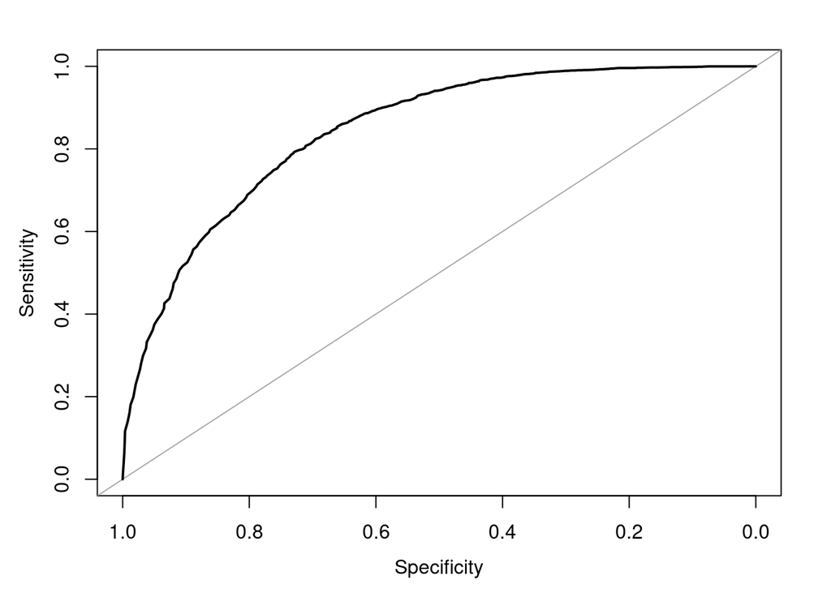

```r
plot(roc_obj, asp=NA)
```

```r
auc(roc_obj)
```

```
## Area under the curve: 0.8432
```

Visualise feature importance (which features contribute most to predictions). Helps interpretability by identifying key factors influencing churn.

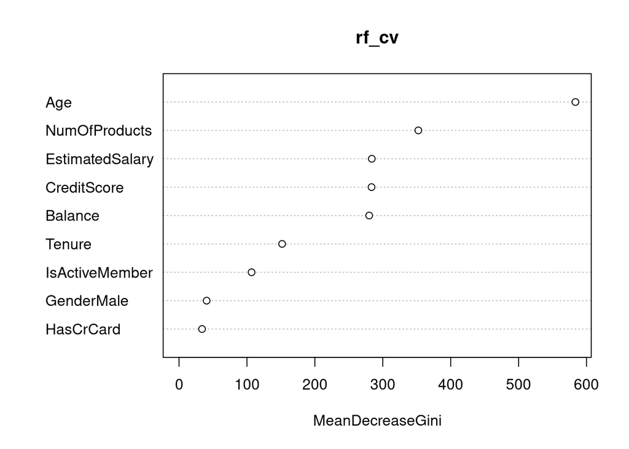

```r
varImpPlot(rf_cv)
```